# Рынок заведений общественного питания Москвы

### Для каждого вида объекта общественного питания - описание среднего количества посадочных мест. Какой вид предоставляет в среднем самое большое количество посадочных мест?

```python
df.groupby('object_type').agg({'number' : 'median'}).sort_values('number', ascending=False)
```

| object_type | number |
| --- | --- |
| столовая | 103.0 |
| ресторан | 80.0 |
| бар | 35.0 |
| буфет | 32.0 |
| кафе | 30.0 |
| кафетерий | 6.0 |
| предприятие быстрого обслуживания | 6.0 |
| закусочная | 0.0 |
| магазин (отдел кулинарии) | 0.0 |

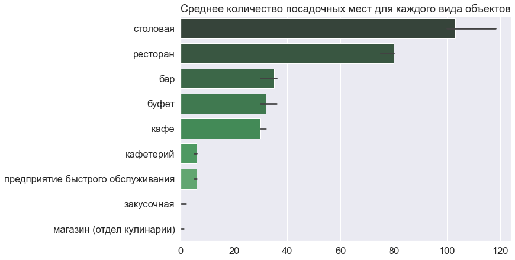

```python
plt.figure(figsize= (10, 7))
result = df.groupby(["object_type"])['number'].aggregate(np.median).reset_index().sort_values('number', ascending=False)
ax=sns.barplot(x='number', y='object_type', data=df, estimator=median, order=result['object_type'])
ax.set_title('Среднее количество посадочных мест для каждого вида объектов')
ax.set_xlabel('')
ax.set_ylabel('')
plt.show();
```

**Вывод**:

- самое большое количество мест в среднем бывает **в столовых** (103 места)
- на втором месте по среднему количеству посадочных мест - рестораны (80 мест)
- бары, буфеты, кафе в среднем предоставляют по 35, 32, 30 мест соответственно
- кафетерии, предприятия быстрого обслуживания в среднем имеют по 6 посадочных мест
- закусочные и магазины(отделы кулинарии) в среднем посадочных мест не предоставляют вообще (0)

### Выделение в отдельный столбец информации об улице из столбца address

```python
# создаём список возможных вариантов всего, что может быть указано на месте улицы
street_names = ['улица', 'шоссе', 'бульвар', 'набережная', 'проспект', 'переулок', 'проезд', 'площадь', 'аллея',
 'линия', 'тракт', 'квартал', 'тупик', 'сквер']

# создаём функцию-поиск, к-ая делит строку с адресом на части по запятым,
# для каждого варианта значения улицы ищет совпадения в частях разрезанной строки address
# при этом мы знаем, если подстрока не найдена, метод find возвращает -1,
# поэтому мы указываем вернуть те части строки, которые не являются не найденными, т.е. != -1
def find_street(address):
    for address_part in address.split(', '):
        for street_name in street_names:
            if address_part.lower().find(street_name) != -1:
                return address_part
```

```python
#создаём новый столбец при помощи применения новой функции к столбцу address
df['street'] = df['address'].apply(find_street)
df.head()
```

|  | id | object_name | chain | object_type | address | number | street |
| --- | --- | --- | --- | --- | --- | --- | --- |
| 0 | 151635 | СМЕТАНА | нет | кафе | город Москва, улица Егора Абакумова, дом 9 | 48 | улица Егора Абакумова |
| 1 | 77874 | Родник | нет | кафе | город Москва, улица Талалихина, дом 2/1, корпус 1 | 35 | улица Талалихина |
| 2 | 24309 | Кафе «Академия» | нет | кафе | город Москва, Абельмановская улица, дом 6 | 95 | Абельмановская улица |
| 3 | 21894 | ПИЦЦЕТОРИЯ | да | кафе | город Москва, Абрамцевская улица, дом 1 | 40 | Абрамцевская улица |
| 4 | 119365 | Кафе «Вишневая метель» | нет | кафе | город Москва, Абрамцевская улица, дом 9, корпус 1 | 50 | Абрамцевская улица |

```python
df['street'].isna().sum()
```

```
381
```

```python
df.loc[df['street'].isna()].head()
```

|  | id | object_name | chain | object_type | address | number | street |
| --- | --- | --- | --- | --- | --- | --- | --- |
| 1405 | 20199 | ЭТО | нет | кафе | город Москва, город Зеленоград, корпус 401 | 35 | None |
| 1406 | 68113 | Френдс | нет | кафе | город Москва, город Зеленоград, корпус 435 | 34 | None |
| 1407 | 20105 | Кафе «Граф Монте-Кристо» | нет | кафе | город Москва, город Зеленоград, корпус 436 | 40 | None |
| 1408 | 22982 | Альфорно | нет | кафе | город Москва, город Зеленоград, корпус 438 | 49 | None |
| 1409 | 151267 | Альфорно | нет | кафе | город Москва, город Зеленоград, корпус 438 | 45 | None |

После применения функции осталось 381 строка с пропусками. Это говорит о том, что в таких строках нестандартные адреса. Если взглянуть на них, то можно встретить, например, "город Москва, город Зеленоград, корпус 401". Такие адреса не содержат нужной нам информации, и с одной стороны, можно было бы заменить None на значения-"заглушки", с другой стороны, они потом могут появиться в искомом "рейтинге" улиц, что нам не нужно. Поэтому оставим их как есть, None.

**Вывод**: данные готовы для дальнейшей работы (исключение составила 381 строка с нестандартными значениями адресов).

### График топ-10 улиц по количеству объектов общественного питания. Информация о том, в каких районах Москвы находятся эти улицы

```python
top_10 = (df.groupby('street', as_index=False).agg({'id':'count'})
          .sort_values(by='id', ascending=False).reset_index(drop=True).head(10))
top_10.columns = ['street', 'id_count']
top_10
```

|  | street | id_count |
| --- | --- | --- |
| 0 | проспект Мира | 204 |
| 1 | Профсоюзная улица | 182 |
| 2 | Ленинградский проспект | 172 |
| 3 | Пресненская набережная | 167 |
| 4 | Варшавское шоссе | 165 |
| 5 | Ленинский проспект | 148 |
| 6 | проспект Вернадского | 128 |
| 7 | Кутузовский проспект | 114 |
| 8 | Каширское шоссе | 111 |
| 9 | Кировоградская улица | 108 |

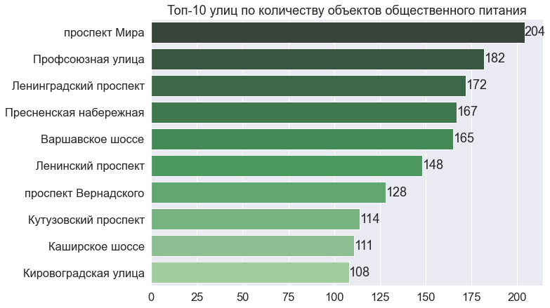

```python
plt.figure(figsize= (10, 7))
ax = sns.barplot(x='id_count', y='street', data=top_10)
ax.set_title('Топ-10 улиц по количеству объектов общественного питания')
ax.set_xlabel('')
ax.set_ylabel('')
for i in ax.containers:
    ax.bar_label(i,)
plt.show();
```

```python
from io import BytesIO
import requests
spreadsheet_id = '12dUSUaQAgy7BXOZBZK4GwgdjHeQKZShc1O1T59qjpGc'
file_name = 'https://docs.google.com/spreadsheets/d/{}/export?format=csv'.format(spreadsheet_id)
r = requests.get(file_name)
df_street = pd.read_csv(BytesIO(r.content))
df_street = df_street.rename(columns={'streetname':'street'})
df_street
```

|  | street | areaid | okrug | area |
| --- | --- | --- | --- | --- |
| 0 | Выставочный переулок | 17 | ЦАО | Пресненский район |
| 1 | улица Гашека | 17 | ЦАО | Пресненский район |
| 2 | Большая Никитская улица | 17 | ЦАО | Пресненский район |
| 3 | Глубокий переулок | 17 | ЦАО | Пресненский район |
| 4 | Большой Гнездниковский переулок | 17 | ЦАО | Пресненский район |
| ... | ... | ... | ... | ... |
| 4393 | Вознесенский проезд | 17 | ЦАО | Пресненский район |
| 4394 | Волков переулок | 17 | ЦАО | Пресненский район |
| 4395 | Поварская улица | 17 | ЦАО | Пресненский район |
| 4396 | Кудринская площадь | 17 | ЦАО | Пресненский район |
| 4397 | Вспольный переулок | 17 | ЦАО | Пресненский район |

4398 rows × 4 columns

```python
top_10_info = top_10.merge(df_street, on = 'street')

top_10_street = (top_10_info.groupby('street', as_index=False).agg({'areaid':'sum','area':'count'})
              .sort_values(by='area', ascending=False).reset_index(drop=True))
top_10_street.columns=['Улица', 'Площадь', 'Количество районов']
top_10_street
```

|  | Улица | Площадь | Количество районов |
| --- | --- | --- | --- |
| 0 | Варшавское шоссе | 895 | 8 |
| 1 | Ленинский проспект | 723 | 8 |
| 2 | проспект Мира | 492 | 7 |
| 3 | Профсоюзная улица | 775 | 6 |
| 4 | проспект Вернадского | 388 | 5 |
| 5 | Каширское шоссе | 414 | 4 |
| 6 | Ленинградский проспект | 244 | 4 |
| 7 | Кировоградская улица | 327 | 3 |
| 8 | Кутузовский проспект | 87 | 2 |
| 9 | Пресненская набережная | 17 | 1 |

```python
top_10_area = (top_10_info.groupby('area', as_index=False).agg({'street':'count'})
              .sort_values(by='street', ascending=False).reset_index(drop=True))
top_10_area.columns=['Район', 'Количество улиц из топ-10']
top_10_area
```

|  | Район | Количество улиц из топ-10 |
| --- | --- | --- |
| 0 | Район Чертаново Центральное | 2 |
| 1 | Донской район | 2 |
| 2 | Ломоносовский район | 2 |
| 3 | Район Проспект Вернадского | 2 |
| 4 | Обручевский район | 2 |
| 5 | Район Теплый Стан | 2 |
| 6 | Район Нагатино-Садовники | 2 |
| 7 | Район Чертаново Южное | 2 |
| 8 | Район Тропарево-Никулино | 2 |
| 9 | Район Гагаринский | 2 |
| 10 | Район Чертаново Северное | 2 |
| 11 | Район Фили-Давыдково | 1 |
| 12 | Район Сокол | 1 |
| 13 | Академический район | 1 |
| 14 | Район Черемушки | 1 |
| 15 | Район Свиблово | 1 |
| 16 | Район Южное Бутово | 1 |
| 17 | Район Якиманка | 1 |
| 18 | Район Ясенево | 1 |
| 19 | Хорошевский район | 1 |
| 20 | Район Северное Бутово | 1 |
| 21 | Район Орехово-Борисово Южное | 1 |
| 22 | Район Ростокино | 1 |
| 23 | Район Раменки | 1 |
| 24 | Алексеевский район | 1 |
| 25 | Район Орехово-Борисово Северное | 1 |
| 26 | Район Москворечье-Сабурово | 1 |
| 27 | Район Марьина роща | 1 |
| 28 | Район Коньково | 1 |
| 29 | Район Дорогомилово | 1 |
| 30 | Район Беговой | 1 |
| 31 | Район Аэропорт | 1 |
| 32 | Пресненский район | 1 |
| 33 | Останкинский район | 1 |
| 34 | Нагорный район | 1 |
| 35 | Мещанский район | 1 |
| 36 | Ярославский Район | 1 |

```python
# создаём функцию, которая вернёт список значений районов
def find_area(row, data):
    result = data[data['street'] == row['street']]['area'].to_list()
    return result
```

```python
# применяем её к первому датафрейму с топ-10 улиц, используя информацию из объединённой таблицы top_10_info
top_10['areas'] = top_10.apply(find_area, args=[top_10_info], axis=1)

# смотрим, что получается
top_10
```

|  | street | id_count | areas |
| --- | --- | --- | --- |
| 0 | проспект Мира | 204 | [Алексеевский район, Ярославский Район, Район ... |
| 1 | Профсоюзная улица | 182 | [Академический район, Район Черемушки, Район Я... |
| 2 | Ленинградский проспект | 172 | [Район Аэропорт, Район Беговой, Хорошевский ра... |
| 3 | Пресненская набережная | 167 | [Пресненский район] |
| 4 | Варшавское шоссе | 165 | [Район Чертаново Центральное, Район Чертаново ... |
| 5 | Ленинский проспект | 148 | [Район Проспект Вернадского, Район Тропарево-Н... |
| 6 | проспект Вернадского | 128 | [Район Проспект Вернадского, Район Раменки, Ра... |
| 7 | Кутузовский проспект | 114 | [Район Дорогомилово, Район Фили-Давыдково] |
| 8 | Каширское шоссе | 111 | [Район Москворечье-Сабурово, Район Нагатино-Са... |
| 9 | Кировоградская улица | 108 | [Район Чертаново Центральное, Район Чертаново ... |

```python
#автоматизируем процесс вывода названия улицы и районов, в которых она расположена
for street, areas in zip(top_10['street'], top_10['areas']):
    print(f'{street} находится в:')
    for area in areas:
        print('-', area)
    print('')
```

```
проспект Мира находится в:
- Алексеевский район
- Ярославский Район
- Район Марьина роща
- Останкинский район
- Район Ростокино
- Район Свиблово
- Мещанский район

Профсоюзная улица находится в:
- Академический район
- Район Черемушки
- Район Ясенево
- Район Коньково
- Обручевский район
- Район Теплый Стан

Ленинградский проспект находится в:
- Район Аэропорт
- Район Беговой
- Хорошевский район
- Район Сокол

Пресненская набережная находится в:
- Пресненский район

Варшавское шоссе находится в:
- Район Чертаново Центральное
- Район Чертаново Северное
- Район Чертаново Южное
- Донской район
- Район Нагатино-Садовники
- Нагорный район
- Район Северное Бутово
- Район Южное Бутово

Ленинский проспект находится в:
- Район Проспект Вернадского
- Район Тропарево-Никулино
- Донской район
```

[output cut: 12 more lines]

```

Кутузовский проспект находится в:
- Район Дорогомилово
- Район Фили-Давыдково

Каширское шоссе находится в:
- Район Москворечье-Сабурово
- Район Нагатино-Садовники
- Район Орехово-Борисово Южное
- Район Орехово-Борисово Северное

Кировоградская улица находится в:
- Район Чертаново Центральное
- Район Чертаново Северное
- Район Чертаново Южное
```

**Вывод**:

- топ-10 улиц по количеству объектов находятся, как правило, в нескольких районах (от 2 до 8), вероятно, это связано с большой протяжённостью улиц. И этот фактор (длина улицы) тоже, очевидно, влияет на количество объектов на ней. Кроме того, все эти улицы - большие транспортные "артерии" города.
- исключение - Пресненская набережная - она находится всего в одном районе и она самая небольшая по длине из этого списка. Но зато она находится в историческом центре (центр притяжения туристов и отдыхающих)